# Lab 2: Differential expression Part 2

April 10, 2014

## This week

The lab on Friday will be an introduction to the cluster. These slides provide solutions to the previous lab exercises.

## Solutions to Lab 1 Exercise 1

You were asked to

- Read about loess/lowess normalization.
- Normalize samples 1 and 2 using the lowess curve that we computed
- How does the MA plot look like after normalization? Does it look better than quantile normalization?

```r
library(affy)
library(affydata)
data(Dilution)
raw <- pm(Dilution)
log.raw <- log2(raw)
avg  <- log.raw[,1] + log.raw[,2]
diff <-  log.raw[,1] - log.raw[,2]
```

## Solutions to Lab 1 Exercise 1

To fit the lowess curve:

```r
lowess.curve <- lowess(x = avg, y = diff, f = 0.05)
names(lowess.curve)
```

```
## [1] "x" "y"
```

**x** corresponds to the sorted variable **avg**, and **y** corresponds to the predicted value of **diff** using the lowess curve. For each value of the vector **avg**, we need to find its corresponding value in the vector **x**. The function **match()** does that for us (see **?match**).

## Solutions to Lab 1 Exercise 1

Lowess normalization:

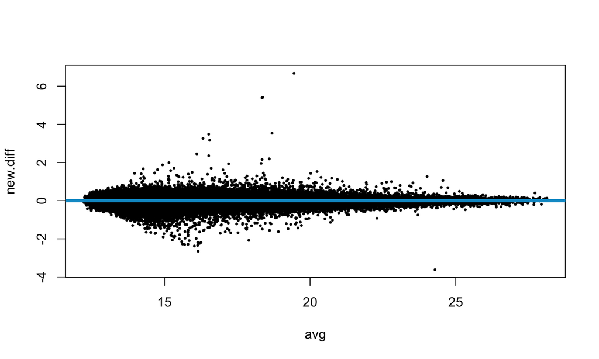

```r
y.predicted <- lowess.curve$y[match(avg, lowess.curve$x)]
new.diff <- diff - y.predicted
plot(avg, new.diff, pch=20, cex=0.5) # MA plot
abline(h=0,col="deepskyblue3", lwd=4)
```

## Solutions to Lab 1 Exercise 1

We have corrected the Avg and Diff values; how can we retrieve the corrected intensities of Array 1 and Array 2? First, we used the bivariate transformation \[ avg = x_1+x_2\] \[ diff = x_1-x_2\] Its inverse transformation is \[ x_1 = \frac{avg+diff}{2}\] \[ x_2 = \frac{avg-diff}{2}\]

## Solutions to Lab 1 Exercise 1

Then

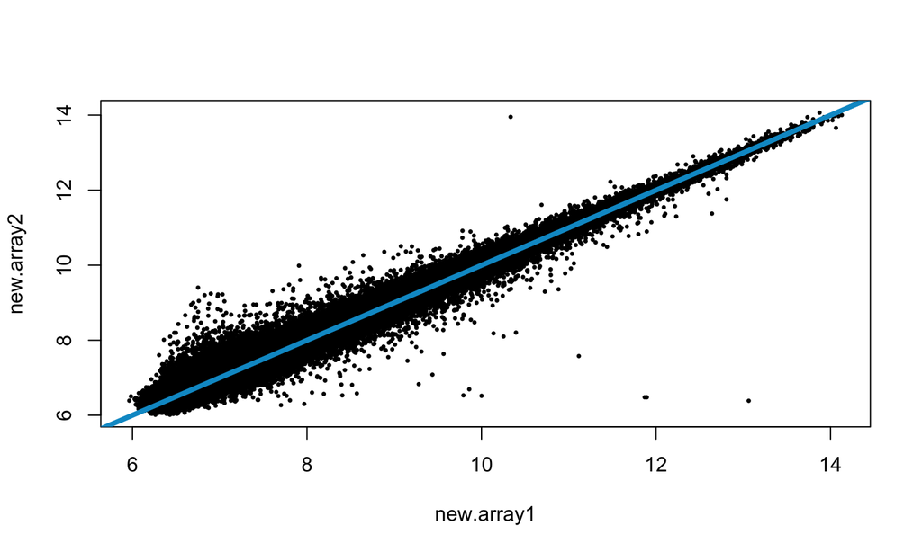

```r
new.array1 <- (avg+new.diff)/2
new.array2 <- (avg-new.diff)/2
plot(new.array1, new.array2, pch=20, cex=0.5)
abline(a=0,b=1,col="deepskyblue3", lwd=4)
```

## Solutions to Lab 1 Exercise 2

We've done it in class. If you'd like to see it one more time, please email me.

## Solutions to Lab 1 Exercise 3

You were asked to

- Repeat the differential expression analysis, but this time testing for the difference between samples from scanner 1 and samples from scanner 2 (see phenotype information)
- Produce a p-values (computed with **eBayes**) histogram
- Repeat the analysis but this time with data that haven't been background corrected and that are not normalized. Use the median polish algorithm for the probeset summarization. Use the function **expresso()** in the **affy** package to produce such an expression matrix.
- What can you tell about the p-values produced with the RMA-corrected dataset? What can you tell about the p-values produced with the uncorrected data?

Let's do it.

## Solutions to Lab 1 Exercise 2

First, let's create our group variable; we want to use the scanner variable this time:

```r
pd <- pData(Dilution)
groups <- as.factor(pd$scanner)
```

and create the corresponding design matrix:

```r
design.matrix <- model.matrix(~groups)
colnames(design.matrix) <- c("Intercept","Scanner")
```

In the first question , we want to use the RMA-corrected expression matrix:

```r
e <- exprs(rma(Dilution))
```

```
## Background correcting
## Normalizing
## Calculating Expression
```

## Solutions to Lab 1 Exercise 2

Then we load **limma** and run a linear model:

```r
library(limma)
fit <- lmFit(e, design.matrix)
```

and compute the moderated t-statistics using Empirical Bayes:

```r
fit2 <- eBayes(fit)
```

What does the histogram of the p-values look like?

## Solutions to Lab 1 Exercise 2

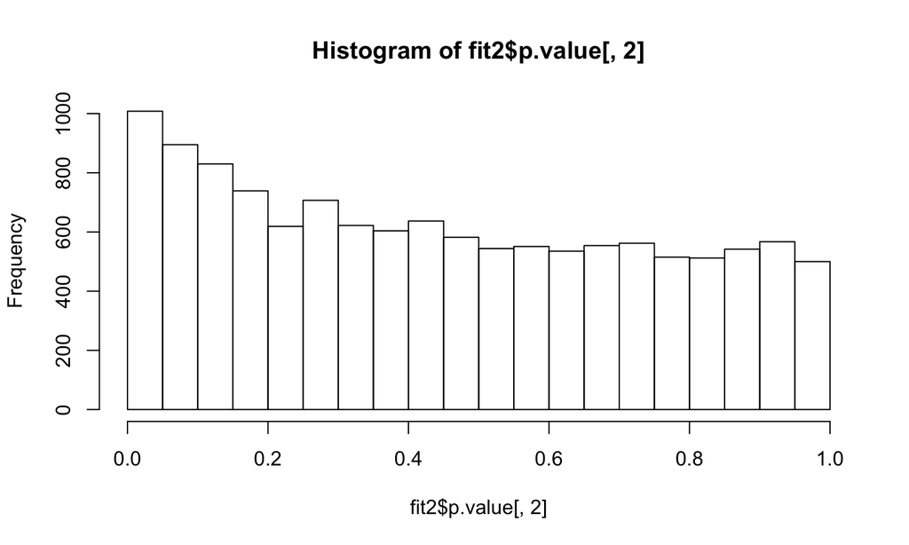

```r
hist(fit2$p.value[,2])
```

What can you tell?

## Solutions to Lab 1 Exercise 2

Let's do it one more time, but without using background correcton and quantile normalization (using the function **expresso**):

```r
e2 <- expresso(Dilution, bg.correct = FALSE, normalize = FALSE,
               pmcorrect.method="pmonly", summary.method = "medianpolish")
```

```
## PM/MM correction : pmonly
## expression values: medianpolish
## 12625 ids to be processed
## |                    |
## |####################|
```

```r
fit3 <- eBayes(lmFit(e2, design.matrix))
```

## Solutions to Lab 1 Exercise 2

Do you think this histogram looks good? What's going on?

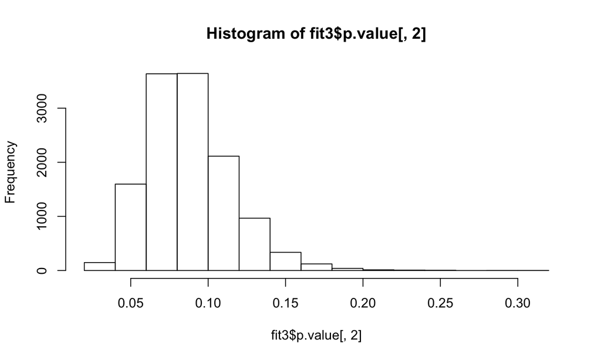

```r
hist(fit3$p.value[,2])
```

## Next

At the beginning of next lab we will

- map the probesets to real genes
- create a nice table of differentially expressed genes ready for publication